# social_project

Revanth

2024-04-29

```r
library(MASS)
library(ggplot2)
library(memisc)
library(ROCR)
library(dplyr)
library(klaR)
library(memisc)
library(ggplot2)
library(corrplot)
library(factoextra)
library(psych)
library(NbClust)
library(caTools)
library(magrittr)
library(pROC)
library(caret)
media <- read.csv('C:/Users/Admin/Desktop/media_new.csv', row.names=1)
str(media)
```

```
## 'data.frame':    21 obs. of  11 variables:
##  $ Instagram_Usage           : num  3.5 7.44 3.46 5.23 0 2.2 5.22 7 8.39 12.1 ...
##  $ LinkedIn_Usage            : num  4 5.12 7 5.19 12.35 ...
##  $ Snapchat_Usage            : num  1 3.41 12.32 1.18 0 ...
##  $ Twitter_Usage             : num  5 12 0 0 12.4 0 0 0 0 0 ...
##  $ Whatsapp_Usage            : num  1 4.11 9.5 5.18 3 12 6 10 6.09 1 ...
##  $ Youtube_Usage             : num  2.5 4.15 1.51 2 3.3 7 3 2 4 3 ...
##  $ OTT                       : num  14.5 12 2 2 2 3 0 3 3 0 ...
##  $ Reddit                    : num  2.5 12 0 0 1 0 0 0 0 0 ...
##  $ Trouble_falling_asleep    : int  0 1 0 0 1 0 0 1 0 0 ...
##  $ Mood.Productivity         : int  1 1 1 1 1 1 1 1 1 0 ...
##  $ Tired.waking.up.in.morning: int  0 0 0 0 1 0 1 1 0 0 ...
```

## Data

### The data is cumulated for each student.

## Data Dictionary :

### Dataset ID: A unique identifier for each student’s data entry.

### Instagram Usage: The duration of usage of the Instagram app.

### LinkedIn Usage: The duration of usage of the LinkedIn app.

### Snapchat Usage: The duration of usage of the Snapchat app.

### Twitter Usage: The duration of usage of the Twitter app.

### Whatsapp Usage: The duration of usage of the WhatsApp app.

### Youtube Usage: The duration of usage of the YouTube app.

### OTT Usage: The duration of usage of Over-the-Top media services.

### Reddit Usage: The duration of usage of the Reddit app.

### Trouble Falling Asleep: Indicates whether the student reported having trouble falling asleep (0: No, 1: Yes).

### Mood Productivity: A subjective measure of the student’s mood and productivity level.(0: Bad, 1: Good)

### Tiredness upon Waking Up in the Morning: Indicates the level of tiredness the student reported upon waking up in the morning (0: Low, 1: High).

## Questions :

### 1. Based on the given variables, can we classify if the student is facing problem while falling asleep or not, which can cause health issues because of social media usage.

### 2. Based on the given variables, can we predict if the student is facing problem while falling asleep or not, which can cause health issues because of social media usage.

## Hypothesis :

### We can predict if the student is getting affected or student is facing problem while falling asleep or not based on the time they have spent on the individual social media apps.

## Analysis and Visualization :

```r
str(media)
```

```
## 'data.frame':    21 obs. of  11 variables:
##  $ Instagram_Usage           : num  3.5 7.44 3.46 5.23 0 2.2 5.22 7 8.39 12.1 ...
##  $ LinkedIn_Usage            : num  4 5.12 7 5.19 12.35 ...
##  $ Snapchat_Usage            : num  1 3.41 12.32 1.18 0 ...
##  $ Twitter_Usage             : num  5 12 0 0 12.4 0 0 0 0 0 ...
##  $ Whatsapp_Usage            : num  1 4.11 9.5 5.18 3 12 6 10 6.09 1 ...
##  $ Youtube_Usage             : num  2.5 4.15 1.51 2 3.3 7 3 2 4 3 ...
##  $ OTT                       : num  14.5 12 2 2 2 3 0 3 3 0 ...
##  $ Reddit                    : num  2.5 12 0 0 1 0 0 0 0 0 ...
##  $ Trouble_falling_asleep    : int  0 1 0 0 1 0 0 1 0 0 ...
##  $ Mood.Productivity         : int  1 1 1 1 1 1 1 1 1 0 ...
##  $ Tired.waking.up.in.morning: int  0 0 0 0 1 0 1 1 0 0 ...
```

```r
summary(media)
```

```
##  Instagram_Usage  LinkedIn_Usage   Snapchat_Usage   Twitter_Usage
##  Min.   : 0.000   Min.   : 1.520   Min.   : 0.000   Min.   : 0.000
##  1st Qu.: 3.500   1st Qu.: 3.450   1st Qu.: 0.000   1st Qu.: 0.000
##  Median : 5.300   Median : 4.000   Median : 1.250   Median : 0.000
##  Mean   : 5.779   Mean   : 5.784   Mean   : 4.046   Mean   : 2.253
##  3rd Qu.: 7.000   3rd Qu.: 7.000   3rd Qu.: 7.190   3rd Qu.: 2.250
##  Max.   :12.200   Max.   :12.480   Max.   :12.320   Max.   :12.400
##  Whatsapp_Usage   Youtube_Usage        OTT             Reddit
##  Min.   : 1.000   Min.   : 0.00   Min.   : 0.000   Min.   : 0.000
##  1st Qu.: 3.210   1st Qu.: 2.00   1st Qu.: 1.000   1st Qu.: 0.000
##  Median : 5.000   Median : 3.00   Median : 2.000   Median : 0.000
##  Mean   : 5.172   Mean   : 3.46   Mean   : 3.455   Mean   : 1.658
##  3rd Qu.: 6.570   3rd Qu.: 4.15   3rd Qu.: 3.000   3rd Qu.: 0.010
##  Max.   :12.000   Max.   :12.48   Max.   :14.500   Max.   :12.300
##  Trouble_falling_asleep Mood.Productivity Tired.waking.up.in.morning
##  Min.   :0.0000         Min.   :0.0000    Min.   :0.0000
##  1st Qu.:0.0000         1st Qu.:1.0000    1st Qu.:0.0000
##  Median :0.0000         Median :1.0000    Median :0.0000
##  Mean   :0.3333         Mean   :0.9524    Mean   :0.3333
##  3rd Qu.:1.0000         3rd Qu.:1.0000    3rd Qu.:1.0000
##  Max.   :1.0000         Max.   :1.0000    Max.   :1.0000
```

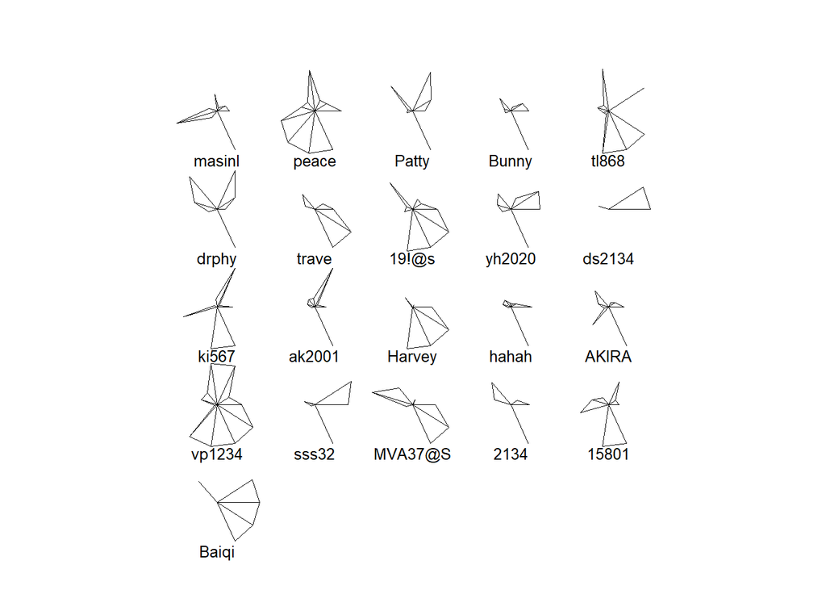

```r
stars(media)
```

```r
correlation_matrix <- cor(media[,1:11])
correlation_matrix
```

```
##                            Instagram_Usage LinkedIn_Usage Snapchat_Usage
## Instagram_Usage                 1.00000000    0.418393819    -0.36795469
## LinkedIn_Usage                  0.41839382    1.000000000    -0.24766218
## Snapchat_Usage                 -0.36795469   -0.247662176     1.00000000
## Twitter_Usage                  -0.21923123    0.107169218     0.14412220
## Whatsapp_Usage                 -0.07161130   -0.046037532     0.18661870
## Youtube_Usage                  -0.10932223   -0.172289710     0.04975799
## OTT                            -0.26512565   -0.263791493     0.22119987
## Reddit                          0.05917577   -0.110041278     0.16176734
## Trouble_falling_asleep         -0.21668097   -0.187526982     0.21523900
## Mood.Productivity              -0.47748564   -0.376671078     0.18542625
## Tired.waking.up.in.morning      0.09383821    0.006570288    -0.22634945
##                            Twitter_Usage Whatsapp_Usage Youtube_Usage
## Instagram_Usage              -0.21923123    -0.07161130  -0.109322225
## LinkedIn_Usage                0.10716922    -0.04603753  -0.172289710
## Snapchat_Usage                0.14412220     0.18661870   0.049757992
## Twitter_Usage                 1.00000000    -0.28572123   0.046000253
## Whatsapp_Usage               -0.28572123     1.00000000   0.216695065
## Youtube_Usage                 0.04600025     0.21669506   1.000000000
## OTT                           0.31248404    -0.37660937  -0.003838841
## Reddit                        0.72184042    -0.08081563   0.107784743
## Trouble_falling_asleep        0.54976868    -0.19204135  -0.122055432
## Mood.Productivity             0.11899514     0.30233285   0.039705963
## Tired.waking.up.in.morning    0.20974248     0.21648298   0.081673262
##                                     OTT      Reddit Trouble_falling_asleep
## Instagram_Usage            -0.265125647  0.05917577             -0.2166810
## LinkedIn_Usage             -0.263791493 -0.11004128             -0.1875270
## Snapchat_Usage              0.221199865  0.16176734              0.2152390
## Twitter_Usage               0.312484039  0.72184042              0.5497687
## Whatsapp_Usage             -0.376609369 -0.08081563             -0.1920414
## Youtube_Usage              -0.003838841  0.10778474             -0.1220554
## OTT                         1.000000000  0.24831031              0.3778199
## Reddit                      0.248310312  1.00000000              0.3701470
## Trouble_falling_asleep      0.377819900  0.37014697              1.0000000
## Mood.Productivity           0.176971554  0.09908893              0.1581139
## Tired.waking.up.in.morning -0.356221375  0.04608834              0.3571429
##                            Mood.Productivity Tired.waking.up.in.morning
## Instagram_Usage                  -0.47748564                0.093838214
## LinkedIn_Usage                   -0.37667108                0.006570288
## Snapchat_Usage                    0.18542625               -0.226349450
## Twitter_Usage                     0.11899514                0.209742477
## Whatsapp_Usage                    0.30233285                0.216482982
## Youtube_Usage                     0.03970596                0.081673262
## OTT                               0.17697155               -0.356221375
## Reddit                            0.09908893                0.046088339
## Trouble_falling_asleep            0.15811388                0.357142857
## Mood.Productivity                 1.00000000                0.158113883
## Tired.waking.up.in.morning        0.15811388                1.000000000
```

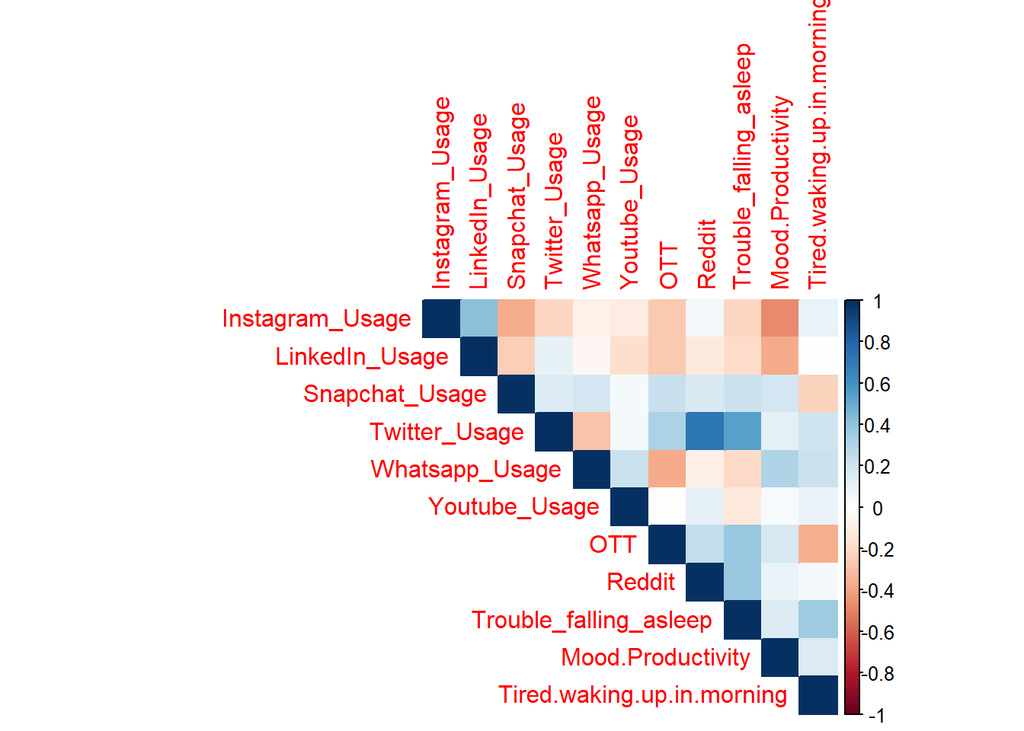

```r
corrplot(cor(media), type = "upper", method = "color")
```

### The correlation matrix shows us a correlation between the columns in both cases.

### Hence, Principal Component Analysis (PCA) can be used to reduce the number of columns for the analysis.

# PCA

```r
media_pca <- prcomp(media[,1:8],scale=TRUE)
media_pca
```

```
## Standard deviations (1, .., p=8):
## [1] 1.5011853 1.3080963 1.1140829 0.9625342 0.8328635 0.7888992 0.6633109
## [8] 0.3341690
##
## Rotation (n x k) = (8 x 8):
##                        PC1         PC2         PC3         PC4        PC5
## Instagram_Usage  0.3518152  0.41804160  0.20974709 -0.11698309  0.5864358
## LinkedIn_Usage   0.2838543  0.44612343  0.21265796  0.32824643 -0.5456590
## Snapchat_Usage  -0.3307725 -0.35081777  0.05593573  0.55442278  0.1139217
## Twitter_Usage   -0.4887728  0.35893938  0.27225188  0.12489011 -0.2930862
## Whatsapp_Usage   0.1786468 -0.46139508  0.50324981  0.26511062  0.1176828
## Youtube_Usage   -0.1066052 -0.27113675  0.47573123 -0.67348774 -0.2925032
## OTT             -0.4555165  0.07337975 -0.38972412 -0.17728868  0.0771824
## Reddit          -0.4433609  0.28726187  0.44951907  0.01692398  0.3925649
##                         PC6         PC7         PC8
## Instagram_Usage  0.39792009  0.07500038  0.36866782
## LinkedIn_Usage   0.38259137 -0.17892337 -0.30215563
## Snapchat_Usage   0.52389724  0.41086720  0.02728941
## Twitter_Usage   -0.21669042  0.02247743  0.63967616
## Whatsapp_Usage  -0.08205273 -0.61616780  0.17723217
## Youtube_Usage    0.35054770  0.16223459 -0.02126972
## OTT              0.45984513 -0.62113043  0.02421276
## Reddit          -0.18107042 -0.03547470 -0.57480937
```

```r
summary(media_pca)
```

```
## Importance of components:
##                           PC1    PC2    PC3    PC4     PC5    PC6    PC7
## Standard deviation     1.5012 1.3081 1.1141 0.9625 0.83286 0.7889 0.6633
## Proportion of Variance 0.2817 0.2139 0.1552 0.1158 0.08671 0.0778 0.0550
## Cumulative Proportion  0.2817 0.4956 0.6507 0.7665 0.85325 0.9310 0.9860
##                            PC8
## Standard deviation     0.33417
## Proportion of Variance 0.01396
## Cumulative Proportion  1.00000
```

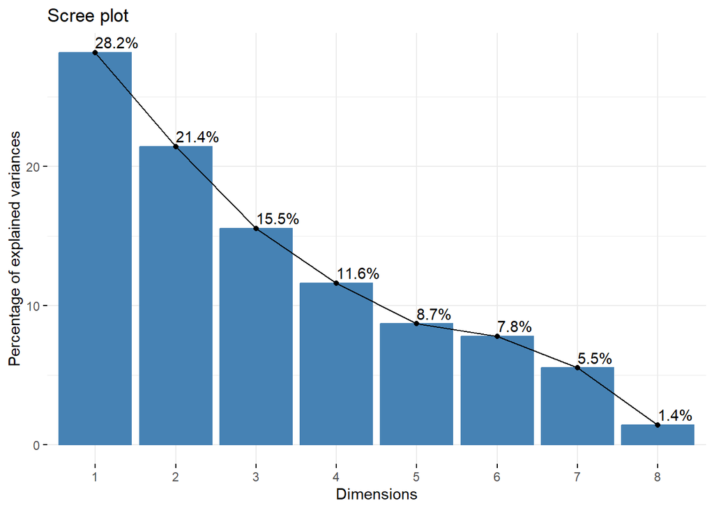

```r
fviz_eig(media_pca, addlabels = TRUE)
```

### The scree diagram shows us that sum of the first 2 principal components is less than 70%.

### So, we cannot move forward using PCA for column reduction.

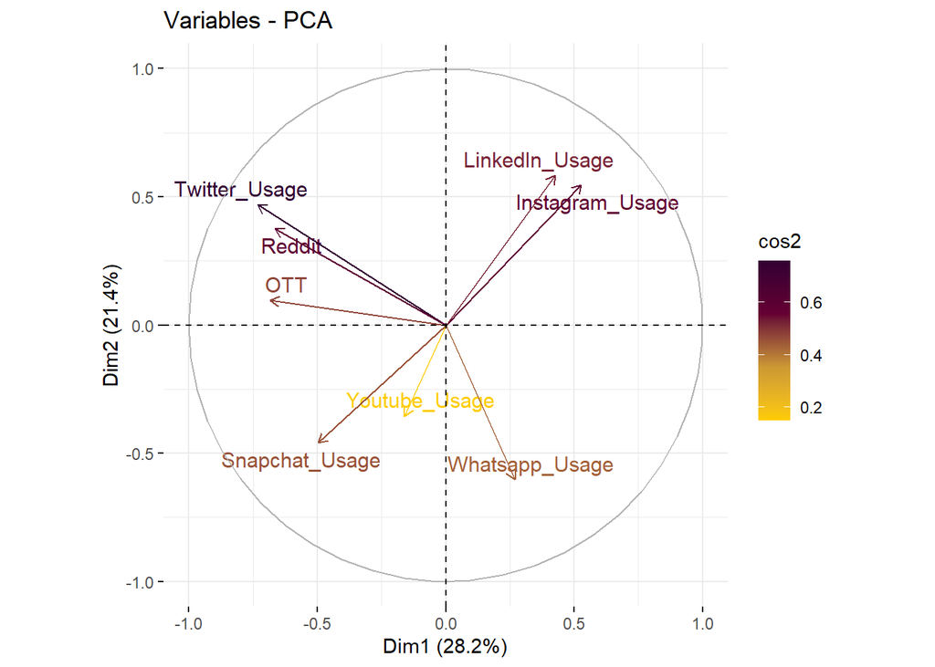

```r
fviz_pca_var(media_pca,col.var = "cos2",
             gradient.cols = c("#FFCC00", "#CC9933", "#660033", "#330033"),
             repel = TRUE)
```

# Factor Analysis

```r
fit.pc <- principal(media[,1:8], nfactors=4, rotate="varimax")
fit.pc
```

```
## Principal Components Analysis
## Call: principal(r = media[, 1:8], nfactors = 4, rotate = "varimax")
## Standardized loadings (pattern matrix) based upon correlation matrix
##                   RC2   RC1   RC3   RC4   h2   u2 com
## Instagram_Usage -0.80  0.00  0.08 -0.08 0.65 0.35 1.0
## LinkedIn_Usage  -0.64  0.16  0.22 -0.43 0.68 0.32 2.2
## Snapchat_Usage   0.75  0.25  0.28 -0.19 0.75 0.25 1.7
## Twitter_Usage    0.07  0.90 -0.21 -0.05 0.87 0.13 1.1
## Whatsapp_Usage   0.18 -0.11  0.86  0.18 0.82 0.18 1.2
## Youtube_Usage    0.03  0.12  0.17  0.90 0.85 0.15 1.1
## OTT              0.42  0.25 -0.68  0.03 0.69 0.31 2.0
## Reddit           0.02  0.90 -0.06  0.14 0.84 0.16 1.1
##
##                        RC2  RC1  RC3  RC4
## SS loadings           1.82 1.80 1.41 1.10
## Proportion Var        0.23 0.23 0.18 0.14
## Cumulative Var        0.23 0.45 0.63 0.77
## Proportion Explained  0.30 0.29 0.23 0.18
## Cumulative Proportion 0.30 0.59 0.82 1.00
##
## Mean item complexity =  1.4
## Test of the hypothesis that 4 components are sufficient.
##
## The root mean square of the residuals (RMSR) is  0.1
##  with the empirical chi square  12.31  with prob <  0.0021
##
## Fit based upon off diagonal values = 0.83
```

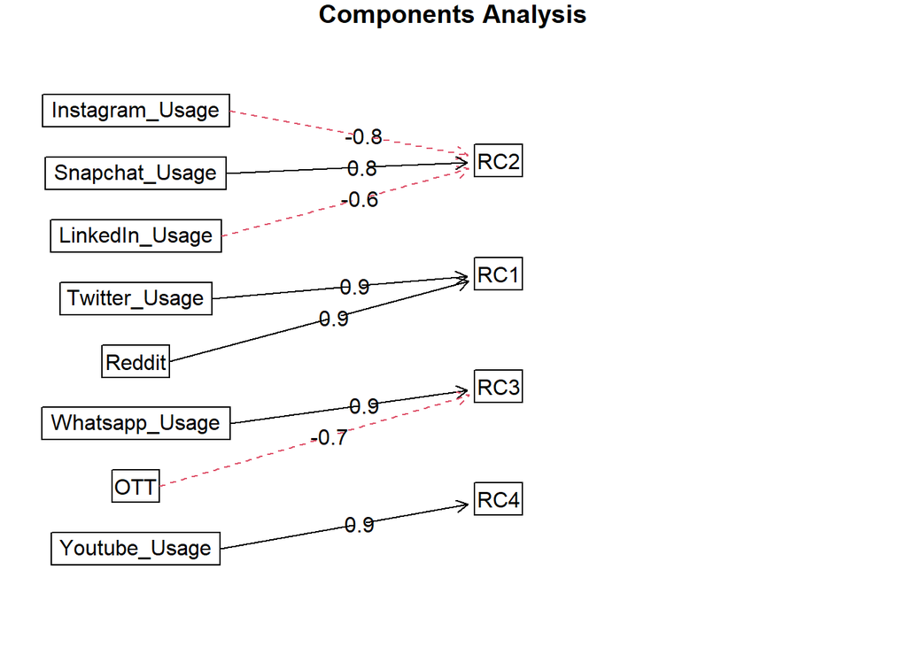

```r
fa.diagram(fit.pc)
```

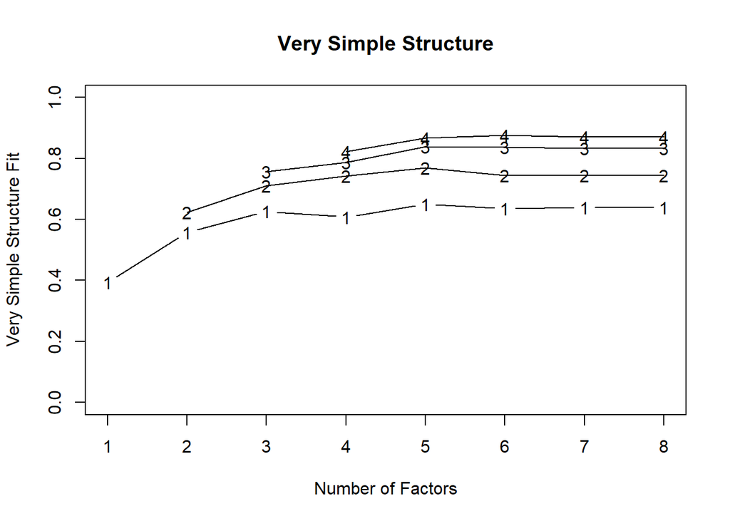

```
##
## Very Simple Structure
## Call: vss(x = media[, 1:8])
## VSS complexity 1 achieves a maximimum of 0.65  with  3  factors
## VSS complexity 2 achieves a maximimum of 0.77  with  5  factors
##
## The Velicer MAP achieves a minimum of 0.09  with  1  factors
## BIC achieves a minimum of  -36.44  with  1  factors
## Sample Size adjusted BIC achieves a minimum of  0.85  with  4  factors
##
## Statistics by number of factors
##   vss1 vss2   map dof   chisq prob sqresid  fit RMSEA   BIC SABIC complex
## 1 0.39 0.00 0.085  20 2.4e+01 0.22     7.0 0.39 0.091 -36.4 25.30     1.0
## 2 0.56 0.62 0.105  13 1.4e+01 0.38     4.3 0.62 0.029 -25.7 14.43     1.2
## 3 0.63 0.71 0.129   7 8.5e+00 0.29     2.8 0.76 0.087 -12.9  8.75     1.4
## 4 0.61 0.74 0.207   2 7.7e-01 0.68     2.0 0.82 0.000  -5.3  0.85     1.8
## 5 0.65 0.77 0.326  -2 1.9e-02   NA     1.4 0.88    NA    NA    NA     1.7
## 6 0.64 0.74 0.472  -5 3.2e-11   NA     1.3 0.89    NA    NA    NA     1.5
## 7 0.64 0.74 1.000  -7 0.0e+00   NA     1.3 0.89    NA    NA    NA     1.5
## 8 0.64 0.74    NA  -8 0.0e+00   NA     1.3 0.89    NA    NA    NA     1.5
##    eChisq    SRMR eCRMS  eBIC
## 1 3.2e+01 1.6e-01 0.195 -29.1
## 2 1.1e+01 9.8e-02 0.143 -28.4
## 3 3.3e+00 5.3e-02 0.105 -18.1
## 4 5.7e-01 2.2e-02 0.082  -5.5
## 5 4.0e-03 1.8e-03    NA    NA
## 6 3.9e-12 5.8e-08    NA    NA
## 7 7.4e-16 7.9e-10    NA    NA
## 8 7.4e-16 7.9e-10    NA    NA
```

```r
vss(media[,1:8])
```

### Defining the factors Obtained-

### RC1 : Content Sharing Platforms

#### Both Twitter and Reddit serve as platforms for social networking, allowing users to connect with others, share content, and engage in discussions.

### RC2 : Popular Social Media

#### Snapchat, LinkedIn, Instagram are popular all over the world.

#### LinkedIn is used for professional purposes. Snapchat is used for chatting and Instagram is used for posting photos and videos.

### RC3 : Chatting and Entertainment

#### Whatsapp & OTT are famous all over the world.

#### Both are used for chatting and entertainment.

### RC4 : Learning Platform

#### Youtube is used for both learning and entertainment.

# Clustering

```r
efa_data <- as.data.frame(fit.pc$scores)
efa_data
```

```
##                 RC2         RC1        RC3         RC4
## masinl   0.50199577  0.13819644 -2.2994808  0.05231959
## peace   -0.21276881  2.54984773 -0.9485184  0.53941315
## Patty    1.25188124 -0.20662132  1.5176849 -1.26457545
## Bunny   -0.09183227 -0.65684816 -0.1250449 -0.24089820
## tl868   -0.24529719  1.12152645 -0.2788583 -0.67514130
## drphy    1.34871513 -0.06310007  1.9952909  0.50674321
## trave   -0.19370853 -0.72149730  0.1217391  0.26337890
## 19!@s    0.15406552 -0.54313701  0.7984383 -0.14138070
## yh2020  -0.74409963 -0.20782042  0.4383534 -0.16343639
## ds2134  -2.07459232 -0.24265930 -0.3540690 -0.50451402
## ki567    1.59809222 -0.29578223 -1.4962368 -1.04345331
## ak2001   1.33991603 -0.24096753  0.1100830 -0.71648736
## Harvey   0.09911595 -0.91264978 -0.4678755 -0.34909645
## hahah   -0.18085176 -0.66483704 -0.5288647  0.02336224
## AKIRA    0.02923532  0.23828979  0.2142207  0.46135378
## vp1234   0.21535039  2.87270180  0.9412799  0.14250026
## sss32   -1.67299124 -0.26285031 -0.4531410 -0.46082853
## MVA37@S -0.31578810 -0.52814396  0.1434725  3.42102127
## 2134    -0.16587275 -0.65019298  0.6438035  1.01049566
## 15801    1.05060721 -0.53983622 -1.0212163  0.49180220
## Baiqi   -1.69117217 -0.18361857  1.0489394 -1.35257856
```

```r
matstd_sm <- scale(efa_data)



res.hc <- matstd_sm %>% scale() %>% dist(method = "euclidean") %>%
  hclust(method = "ward.D2")

res.nbclust <- matstd_sm %>% scale() %>% NbClust(distance = "euclidean", min.nc = 3, max.nc = 13, method = "complete", index ="all")
```

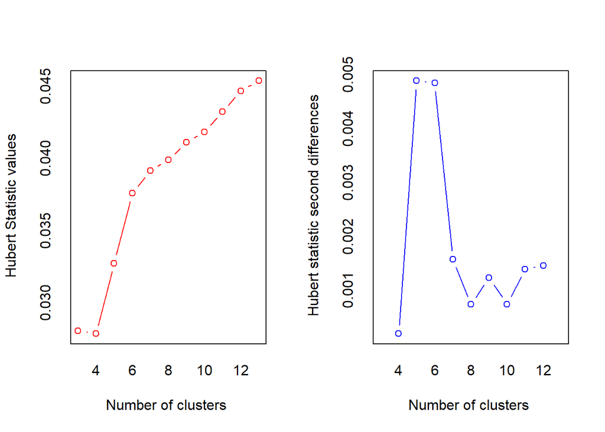

```
## *** : The Hubert index is a graphical method of determining the number of clusters.
##                 In the plot of Hubert index, we seek a significant knee that corresponds to a
##                 significant increase of the value of the measure i.e the significant peak in Hubert
##                 index second differences plot.
##
```

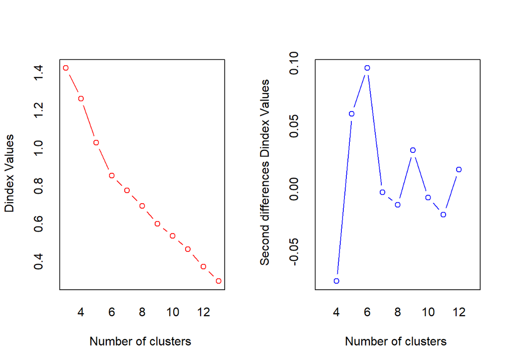

```
## *** : The D index is a graphical method of determining the number of clusters.
##                 In the plot of D index, we seek a significant knee (the significant peak in Dindex
##                 second differences plot) that corresponds to a significant increase of the value of
##                 the measure.
##
## * Among all indices:
## * 4 proposed 3 as the best number of clusters
## * 2 proposed 4 as the best number of clusters
## * 6 proposed 5 as the best number of clusters
## * 3 proposed 6 as the best number of clusters
## * 1 proposed 7 as the best number of clusters
## * 1 proposed 9 as the best number of clusters
## * 1 proposed 10 as the best number of clusters
## * 1 proposed 11 as the best number of clusters
## * 4 proposed 13 as the best number of clusters
##
##                    ***** Conclusion *****
##
## * According to the majority rule, the best number of clusters is  5
##
##
```

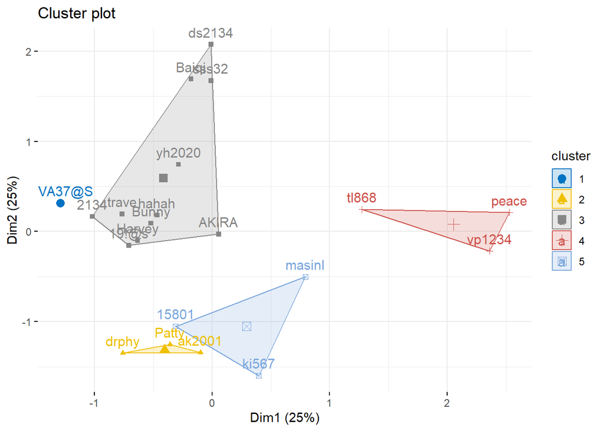

```r
km.res <- kmeans(matstd_sm, 5, nstart = 10)

fviz_cluster(km.res, data = matstd_sm,
             ellipse.type = "convex",
             palette = "jco",
             ggtheme = theme_minimal())
```

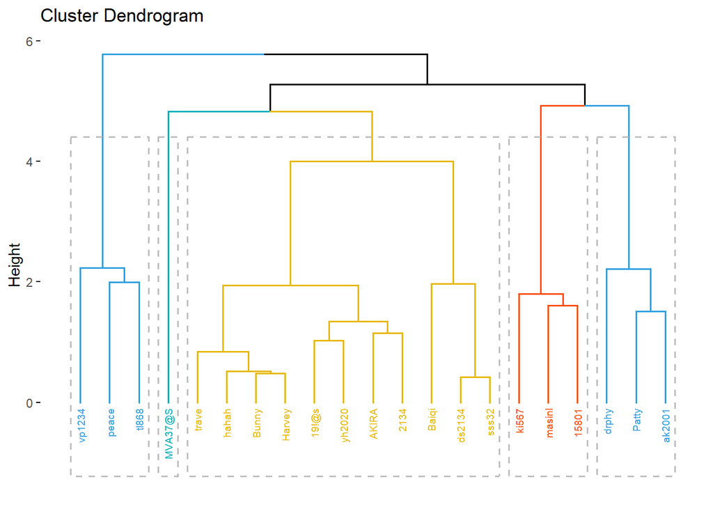

```r
dist.media <- dist(matstd_sm, method="euclidean")



fviz_dend(res.hc, k = 5, # Cut in four groups
          cex = 0.5, # label size
          k_colors = c("#2E9FDF", "#00AFBB", "#E7B800", "#FC4E07"),
          color_labels_by_k = TRUE, # color labels by groups
          rect = TRUE # Add rectangle around groups
)
```

```r
Clustered <- ifelse(km.res$cluster > 1.5, "No Trouble in Sleep", "Trouble in sleep")
Actual <- ifelse(media$Trouble_falling_asleep == 1, "Trouble Sleep", "No trouble in sleep")
confusion_mat <- table(Clustered, Actual)
confusion_mat
```

```
##                      Actual
## Clustered             No trouble in sleep Trouble Sleep
##   No Trouble in Sleep                  13             7
##   Trouble in sleep                      1             0
```

```r
accuracy <- sum(diag(confusion_mat)) / sum(confusion_mat)
precision <- confusion_mat[2, 2] / sum(confusion_mat[, 2])
recall <- confusion_mat[2, 2] / sum(confusion_mat[2, ])
cat("Accuracy:", round(accuracy, 3), "\n")
```

```
## Accuracy: 0.619
```

```r
cat("Precision:", round(precision, 3), "\n")
```

```
## Precision: 0
```

```r
cat("Recall:", round(recall, 3), "\n")
```

```
## Recall: 0
```

### We can see that the confusion matrix shows the clustering is done in a way where almost all the users are not feeling any trouble in falling asleep .

### This shows that we cannot classify our data into trouble falling asleep yes or no based on the variables given.

# Regression

```r
wdbc <-read.csv('C:/Users/Admin/Desktop/media_new.csv')
features <- c("Instagram", "LinkedIn", "Snapchat", "Twitter", "Whatsapp", "Youtube", "OTT", "Reddit", "Trouble_sleep", "Mood", "Tired_morning")
names(wdbc) <- c("ID", "Instagram", "LinkedIn", "Snapchat", "Twitter", "Whatsapp", "Youtube", "OTT", "Reddit", "Trouble_sleep", "Mood", "Tired_morning")
wdbc<- wdbc
wdbc.data <- as.matrix(wdbc[,c(2:9)])
row.names(wdbc.data) <- wdbc$ID
```

## Data Split

```r
wdbc_raw <- cbind(wdbc.data, as.numeric(as.factor(wdbc$Trouble_sleep))-1)
colnames(wdbc_raw)[9] <- "TroubleInSleep"
smp_size_raw <- floor(0.70 * nrow(wdbc_raw))
train_ind_raw <- sample(nrow(wdbc_raw), size = smp_size_raw)
train_raw.df <- as.data.frame(wdbc_raw[train_ind_raw, ])
test_raw.df <- as.data.frame(wdbc_raw[-train_ind_raw, ])
```

### Now divided the dataset into training and testing data for regression analysis.

### We consider the training and testing data with a 70-30 split.

# Multiple Regression:

### Multiple regression is a statistical technique used to understand the relationship between one dependent variable and two or more independent variables.

### It aims to predict the value of the dependent variable based on the values of the independent variables.

```r
x_sm <- cbind(train_ind_raw,train_raw.df[, -9])

fit <- lm(TroubleInSleep ~ ., data = train_raw.df)

summary(fit)
```

```
##
## Call:
## lm(formula = TroubleInSleep ~ ., data = train_raw.df)
##
## Residuals:
##     19!@s   MVA37@S    ds2134     Bunny     trave     15801      2134     drphy
##  0.628192 -0.129332  0.025929 -0.187376 -0.196336  0.723663 -0.153267 -0.132413
##     Baiqi     Patty     AKIRA    yh2020    masinl     tl868
## -0.028497 -0.379252  0.164655 -0.007923 -0.549695  0.221651
##
## Coefficients:
##              Estimate Std. Error t value Pr(>|t|)
## (Intercept)  0.369856   1.005029   0.368    0.728
## Instagram    0.039475   0.155423   0.254    0.810
## LinkedIn    -0.064206   0.131586  -0.488    0.646
## Snapchat     0.034012   0.102022   0.333    0.752
## Twitter      0.111934   0.159386   0.702    0.514
## Whatsapp    -0.003959   0.081978  -0.048    0.963
## Youtube     -0.033001   0.065348  -0.505    0.635
## OTT         -0.004665   0.071610  -0.065    0.951
## Reddit      -0.056428   0.091700  -0.615    0.565
##
## Residual standard error: 0.561 on 5 degrees of freedom
## Multiple R-squared:  0.3325, Adjusted R-squared:  -0.7356
## F-statistic: 0.3113 on 8 and 5 DF,  p-value: 0.9305
```

```r
coefficients(fit)
```

```
##  (Intercept)    Instagram     LinkedIn     Snapchat      Twitter     Whatsapp
##  0.369855802  0.039475356 -0.064206180  0.034011809  0.111933758 -0.003958729
##      Youtube          OTT       Reddit
## -0.033001353 -0.004665387 -0.056427974
```

```r
residuals(fit)
```

```
##        19!@s      MVA37@S       ds2134        Bunny        trave        15801
##  0.628192149 -0.129331671  0.025929336 -0.187376082 -0.196336011  0.723662813
##         2134        drphy        Baiqi        Patty        AKIRA       yh2020
## -0.153266770 -0.132412971 -0.028496733 -0.379252027  0.164655267 -0.007923344
##       masinl        tl868
## -0.549695277  0.221651321
```

```r
probabilities_sm2 <- predict(fit, newdata = test_raw.df, type = "response")

predicted_sm2 <- ifelse(probabilities_sm2 > 0.5, "Yes", "No")
actual_sm <- ifelse(test_raw.df$TroubleInSleep == 1, "Yes", "No")
confusion_sm2 <- table(predicted_sm2, actual_sm)
confusion_sm2
```

```
##              actual_sm
## predicted_sm2 No Yes
##           No   2   1
##           Yes  1   3
```

```r
threshold<-0.5
predicted <- predict(fit, newdata = test_raw.df)

predicted_category <- ifelse(predicted > threshold, "No Trouble in Sleep", "Trouble in sleep")

# Convert actual values to binary categories
actual_category <- ifelse(test_raw.df$TroubleInSleep == 1, "No Trouble in sleep", "Trouble in sleep")

# Create a confusion matrix
confusion_mat <- table(predicted_category, actual_category)

# Calculate accuracy
accuracy <- sum(diag(confusion_mat)) / sum(confusion_mat)
accuracy
```

```
## [1] 0.7142857
```

```r
roc_sm <- roc(test_raw.df$TroubleInSleep, probabilities_sm2)
```

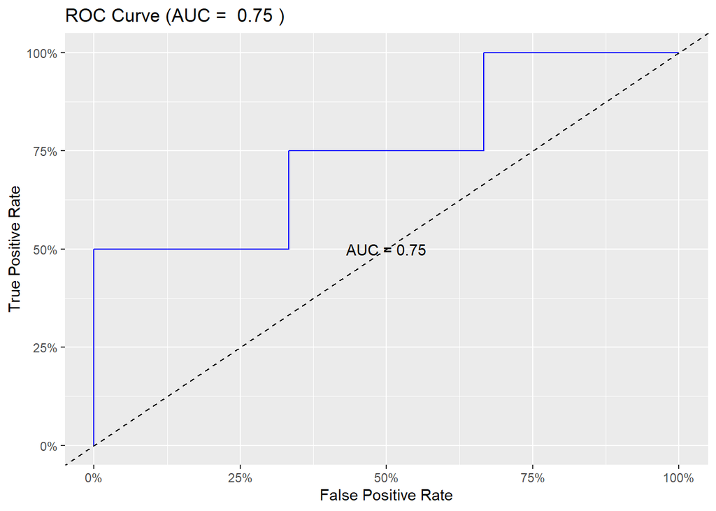

```r
auc_sm <- auc(roc_sm)

ggroc(roc_sm, color = "blue", legacy.axes = TRUE) +
  geom_abline(intercept = 0, slope = 1, linetype = "dashed") +
  scale_x_continuous(labels = scales::percent_format()) +
  scale_y_continuous(labels = scales::percent_format()) +
  labs(x = "False Positive Rate", y = "True Positive Rate",
       title = paste("ROC Curve (AUC = ", round(auc_sm, 2), ")")) +
  annotate("text", x = 0.5, y = 0.5, label = paste0("AUC = ", round(auc_sm, 2)))
```

# Logistic Regression:

### Logistic regression is a statistical method used for binary classification problems. It predicts the probability that a given observation belongs to one of two classes.

### It models the relationship between a binary dependent variable and one or more independent variables.

```r
logistic_sm <- glm(TroubleInSleep ~ ., data = train_raw.df, family = 'binomial')
summary(logistic_sm)
```

```
##
## Call:
## glm(formula = TroubleInSleep ~ ., family = "binomial", data = train_raw.df)
##
## Coefficients:
##               Estimate Std. Error z value Pr(>|z|)
## (Intercept) -5.852e+01  3.185e+05   0.000        1
## Instagram    4.434e+00  4.800e+04   0.000        1
## LinkedIn    -5.260e+00  4.049e+04   0.000        1
## Snapchat    -6.704e-01  2.891e+04   0.000        1
## Twitter      1.550e+01  4.713e+04   0.000        1
## Whatsapp     5.330e+00  3.418e+04   0.000        1
## Youtube     -3.364e+00  1.831e+04   0.000        1
## OTT          9.301e+00  2.796e+04   0.000        1
## Reddit      -6.747e+01  1.176e+05  -0.001        1
##
## (Dispersion parameter for binomial family taken to be 1)
##
##     Null deviance: 1.4548e+01  on 13  degrees of freedom
## Residual deviance: 5.0491e-10  on  5  degrees of freedom
## AIC: 18
##
## Number of Fisher Scoring iterations: 25
```

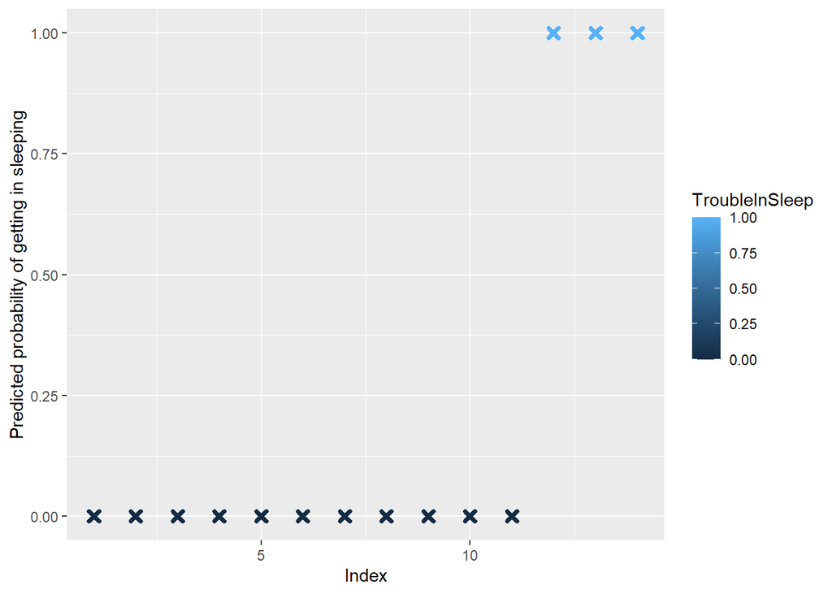

```r
predicted.data <- data.frame(probability.of.hd=logistic_sm$fitted.values,TroubleInSleep=train_raw.df$TroubleInSleep)
predicted.data <- predicted.data[order(predicted.data$probability.of.hd, decreasing=FALSE),]
predicted.data$rank <- 1:nrow(predicted.data)

ggplot(data=predicted.data, aes(x=rank, y=probability.of.hd)) +
  geom_point(aes(color=TroubleInSleep), alpha=1, shape=4, stroke=2) +
  xlab("Index") +
  ylab("Predicted probability of getting in sleeping")
```

```r
probabilities_sm2 <- predict(logistic_sm, newdata = test_raw.df, type = "response")

predicted_sm2 <- ifelse(probabilities_sm2 > 0.5, "Yes", "No")
actual_sm <- ifelse(test_raw.df$TroubleInSleep == 1, "Yes", "No")
confusion_sm2 <- table(predicted_sm2, actual_sm)
confusion_sm2
```

```
##              actual_sm
## predicted_sm2 No Yes
##           No   3   3
##           Yes  0   1
```

```r
accuracy2 <- sum(diag(confusion_sm2)) / sum(confusion_sm2)
precision2 <- confusion_sm2[2, 2] / sum(confusion_sm2[, 2])
recall2 <- confusion_sm2[2, 2] / sum(confusion_sm2[2, ])
cat("Accuracy:", round(accuracy2, 3), "\n")
```

```
## Accuracy: 0.571
```

```r
cat("Precision:", round(precision2, 3), "\n")
```

```
## Precision: 0.25
```

```r
cat("Recall:", round(recall2, 3), "\n")
```

```
## Recall: 1
```

```r
probabilities <- predict(logistic_sm, newdata = test_raw.df, type = "response")

roc_sm <- roc(test_raw.df$TroubleInSleep, probabilities_sm2)
```

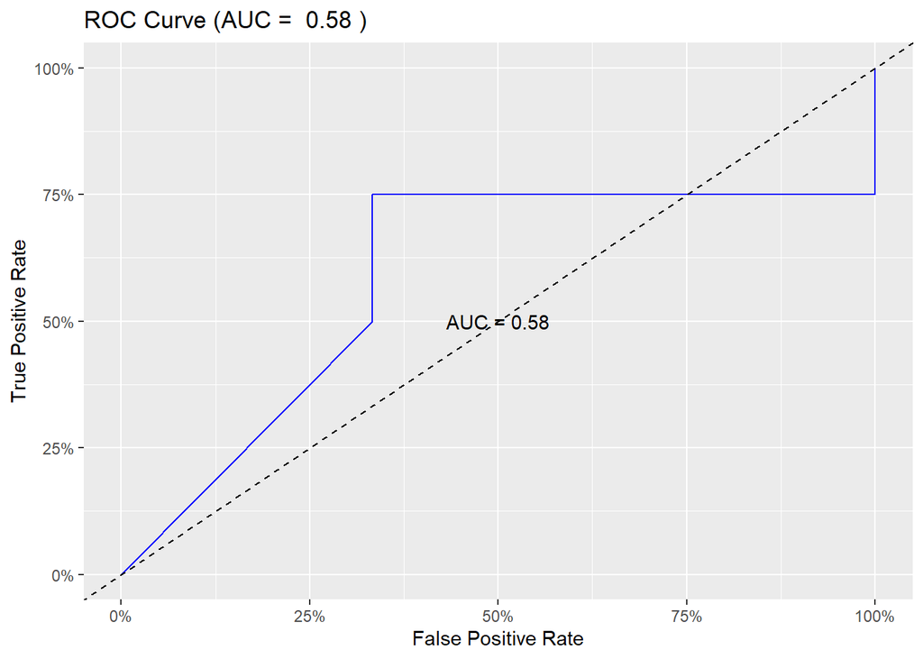

```r
auc_sm <- auc(roc_sm)

ggroc(roc_sm, color = "blue", legacy.axes = TRUE) +
  geom_abline(intercept = 0, slope = 1, linetype = "dashed") +
  scale_x_continuous(labels = scales::percent_format()) +
  scale_y_continuous(labels = scales::percent_format()) +
  labs(x = "False Positive Rate", y = "True Positive Rate",
       title = paste("ROC Curve (AUC = ", round(auc_sm, 2), ")")) +
  annotate("text", x = 0.5, y = 0.5, label = paste0("AUC = ", round(auc_sm, 2)))
```

### These visualizations provide valuable insights into the logistic regression model’s performance by showcasing Accuracy and ROC Curve of the model.

# Discriminant Analysis

```r
wdbc_raw.lda <- lda(formula = TroubleInSleep ~ ., data = train_raw.df)
wdbc_raw.lda
```

```
## Call:
## lda(TroubleInSleep ~ ., data = train_raw.df)
##
## Prior probabilities of groups:
##         0         1
## 0.7857143 0.2142857
##
## Group means:
##   Instagram LinkedIn Snapchat   Twitter Whatsapp  Youtube      OTT    Reddit
## 0  6.233636 6.368182 3.004545 0.4545455 6.401818 3.969091 2.575455 0.8636364
## 1  3.336667 6.640000 3.396667 4.1333333 5.403333 3.466667 5.000000 0.3333333
##
## Coefficients of linear discriminants:
##                   LD1
## Instagram  0.18906801
## LinkedIn  -0.30751678
## Snapchat   0.16290024
## Twitter    0.53610897
## Whatsapp  -0.01896041
## Youtube   -0.15806064
## OTT       -0.02234496
## Reddit    -0.27026291
```

```r
summary(wdbc_raw.lda)
```

```
##         Length Class  Mode
## prior    2     -none- numeric
## counts   2     -none- numeric
## means   16     -none- numeric
## scaling  8     -none- numeric
## lev      2     -none- character
## svd      1     -none- numeric
## N        1     -none- numeric
## call     3     -none- call
## terms    3     terms  call
## xlevels  0     -none- list
```

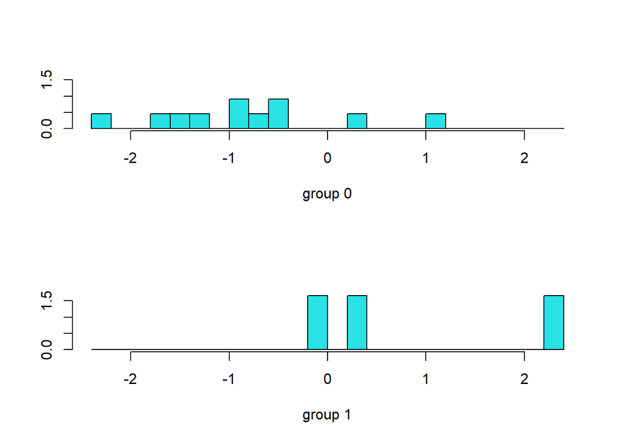

```r
plot(wdbc_raw.lda)
```

```r
predictions <- predict(wdbc_raw.lda, newdata = test_raw.df)
predicted_classes <- predictions$class
accuracy2 <- mean(predicted_classes == test_raw.df$TroubleInSleep)
accuracy2
```

```
## [1] 0.7142857
```

```r
wdbc_raw.lda.predict_train <- predict(wdbc_raw.lda, newdata = train_raw.df)
y<-wdbc_raw.lda.predict_train$class
wdbc_raw.lda.predict_train$x
```

```
##                 LD1
## 19!@s    0.75445542
## MVA37@S -0.40688909
## ds2134  -1.15051477
## Bunny   -0.12888422
## trave   -0.08597046
## 15801    0.29719677
## 2134    -0.29225145
## drphy   -0.39213114
## Baiqi   -0.88984003
## Patty    0.79010945
## AKIRA   -1.81494539
## yh2020  -0.98837669
## masinl   1.60645079
## tl868    2.70159082
```

```r
table(y,train_raw.df$TroubleInSleep)
```

```
##
## y    0  1
##   0 10  2
##   1  1  1
```

```r
wdbc_raw.lda.predict_test <- predict(wdbc_raw.lda, newdata = test_raw.df)
y<-wdbc_raw.lda.predict_test$class
wdbc_raw.lda.predict_test$x
```

```
##              LD1
## peace   3.320910
## ki567   3.684529
## ak2001  3.513437
## Harvey  1.205067
## hahah   1.208467
## vp1234  4.813927
## sss32  -1.879548
```

```r
table(y,test_raw.df$TroubleInSleep)
```

```
##
## y   0 1
##   0 2 1
##   1 1 3
```

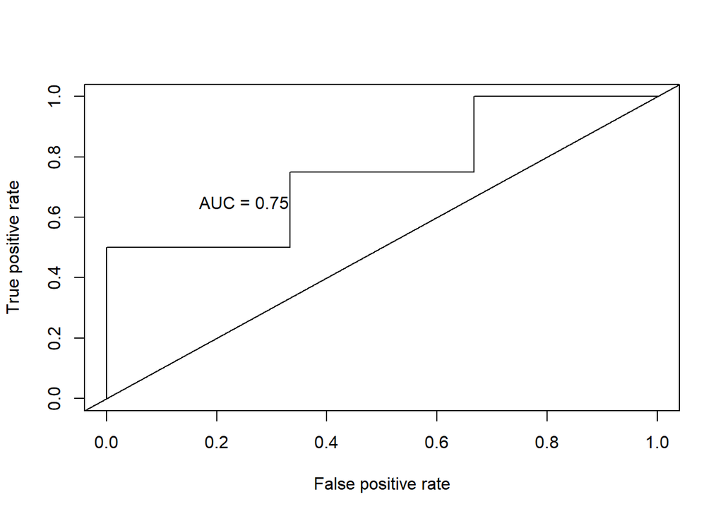

```r
wdbc_raw.lda.predict.posteriors <- as.data.frame(wdbc_raw.lda.predict_test$posterior)
pred <- prediction(wdbc_raw.lda.predict.posteriors[,2], test_raw.df$TroubleInSleep)
roc.perf = performance(pred, measure = "tpr", x.measure = "fpr")
auc.train <- performance(pred, measure = "auc")
auc.train <- auc.train@y.values
plot(roc.perf)
abline(a=0, b= 1)
text(x = .25, y = .65 ,paste("AUC = ", round(auc.train[[1]],3), sep = ""))
```

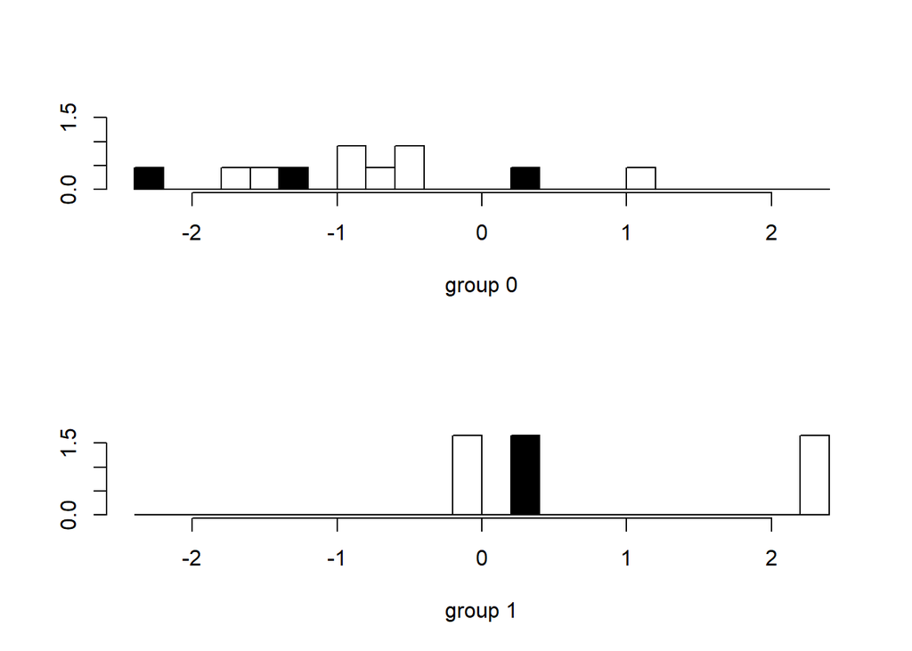

```r
plot(wdbc_raw.lda, col = as.integer(train_raw.df$TroubleInSleep))
```